# Tugas Pertemuan 4

# Bagian 1: Proses MA(2)

## Model MA(2)

Proses MA(2) dapat dituliskan sebagai berikut:

$$Y_t = e_t+\theta_1e_{t-1}+\theta_2e_{t-2}$$

dengan $\theta_1=0.4$ dan $\theta_2=0.6$.

## Pembangkitan Data

### Secara Manual

Karena proses MA(2) melibatkan dua nilai *white noise* sebelumnya, dua nilai pertama *white noise* digunakan sebagai nilai awal.

```r
set.seed(1234)
n <- 300
wn.ma2 <- rnorm(n)

theta1 <- 0.4
theta2 <- 0.6

ma2 <- wn.ma2[1:2]
for(i in 3:n){
  ma2[i] <- wn.ma2[i] + theta1*wn.ma2[i-1] + theta2*wn.ma2[i-2]
}
head(ma2, 10)
```

```
##  [1] -1.2070657  0.2774292  0.4711734 -1.7454637  0.1415103 -0.7297129
##  [7] -0.1148428 -0.4728943 -1.1279487 -1.4437977
```

### Menggunakan `arima.sim()`

```r
set.seed(1234)
ma2.sim <- arima.sim(list(order=c(0,0,2), ma=c(theta1,theta2)), n=n)
head(ma2.sim, 10)
```

```
## Time Series:
## Start = 1
## End = 10
## Frequency = 1
##  [1]  0.4711734 -1.7454637  0.1415103 -0.7297129 -0.1148428 -0.4728943
##  [7] -1.1279487 -1.4437977 -1.1718790 -1.7232862
```

## Karakteristik MA(2)

### Plot Time Series

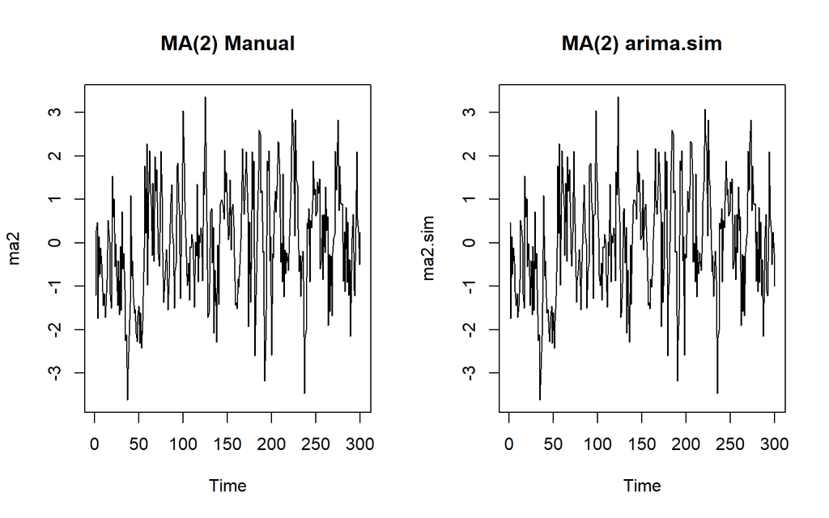

```r
par(mfrow=c(1,2))
ts.plot(ma2, main="MA(2) Manual")
ts.plot(ma2.sim, main="MA(2) arima.sim")
```

```r
par(mfrow=c(1,1))
```

Berdasarkan kedua plot time series tersebut, terlihat bahwa data berfluktuasi secara acak di sekitar rataan nol tanpa membentuk tren maupun perubahan ragam yang berarti, sehingga data MA(2) yang dibangkitkan **stasioner dalam rataan**.

### Plot ACF

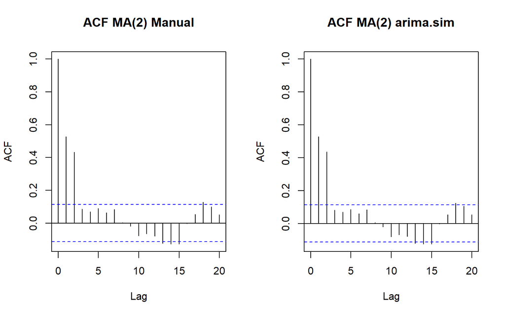

```r
par(mfrow=c(1,2))
acf(ma2, lag.max=20, main="ACF MA(2) Manual")
acf(ma2.sim, lag.max=20, main="ACF MA(2) arima.sim")
```

```r
par(mfrow=c(1,1))
```

Berdasarkan plot ACF tersebut, terlihat bahwa plot ACF *cuts off* setelah lag ke-2, sesuai dengan teori MA(2) di mana autokorelasi hanya signifikan sampai lag $q=2$ kemudian terputus.

### Plot PACF

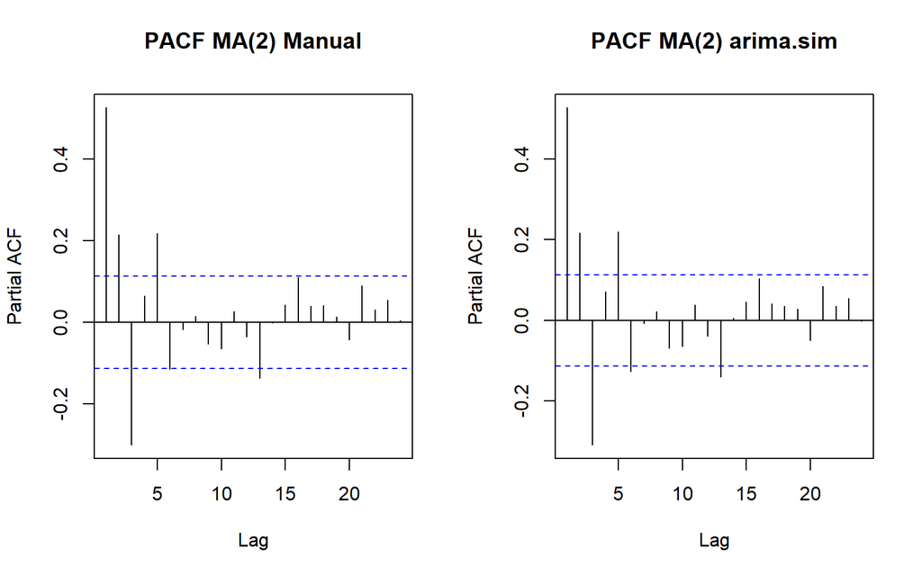

```r
par(mfrow=c(1,2))
pacf(ma2, main="PACF MA(2) Manual")
pacf(ma2.sim, main="PACF MA(2) arima.sim")
```

```r
par(mfrow=c(1,1))
```

Berdasarkan plot PACF tersebut, terlihat bahwa plot PACF cenderung *tails off* dan membentuk gelombang sinus, sesuai dengan karakteristik umum proses MA.

### Plot EACF

```r
TSA::eacf(ma2)
```

```
## AR/MA
##   0 1 2 3 4 5 6 7 8 9 10 11 12 13
## 0 x x o o o o o o o o o  o  x  x
## 1 x x x o o o o o o o o  o  o  o
## 2 x x x x o o o o o o o  o  o  o
## 3 x x x x x o o o o o o  o  o  o
## 4 x x x x x o o o o o o  o  o  o
## 5 x x x x x o x o o o o  o  o  o
## 6 x x x o x o o x o o o  o  o  o
## 7 x o x o x o o x o o o  o  o  o
```

```r
TSA::eacf(ma2.sim)
```

```
## AR/MA
##   0 1 2 3 4 5 6 7 8 9 10 11 12 13
## 0 x x o o o o o o o o o  o  x  x
## 1 x x x o o o o o o o o  o  o  o
## 2 x x x x o o o o o o o  o  o  o
## 3 x x x x o o o o o o o  o  o  o
## 4 x x x x o o o o o o o  o  o  o
## 5 x x o x x o x o o o o  o  o  o
## 6 o x o o x o o x o o o  o  o  o
## 7 x o x o x o o x o o o  o  o  o
```

Berdasarkan pola segitiga nol pada plot EACF, terlihat bahwa segitiga nol berada pada ordo AR(0) dan ordo MA(2), sesuai dengan model yang dibangkitkan.

### Identifikasi Kestasioneran

Proses MA berorde hingga dengan ragam *white noise* terhingga **selalu stasioner** tanpa syarat pada nilai koefisiennya. Hal ini didukung oleh plot time series yang berfluktuasi konstan di sekitar rataan nol serta plot ACF yang *cuts off* pada lag ke-2. Dengan demikian, data MA(2) hasil bangkitan bersifat **stasioner**.

## Scatterplot Antar Lag

### Korelasi antara $Y_t$ dengan $Y_{t-1}$

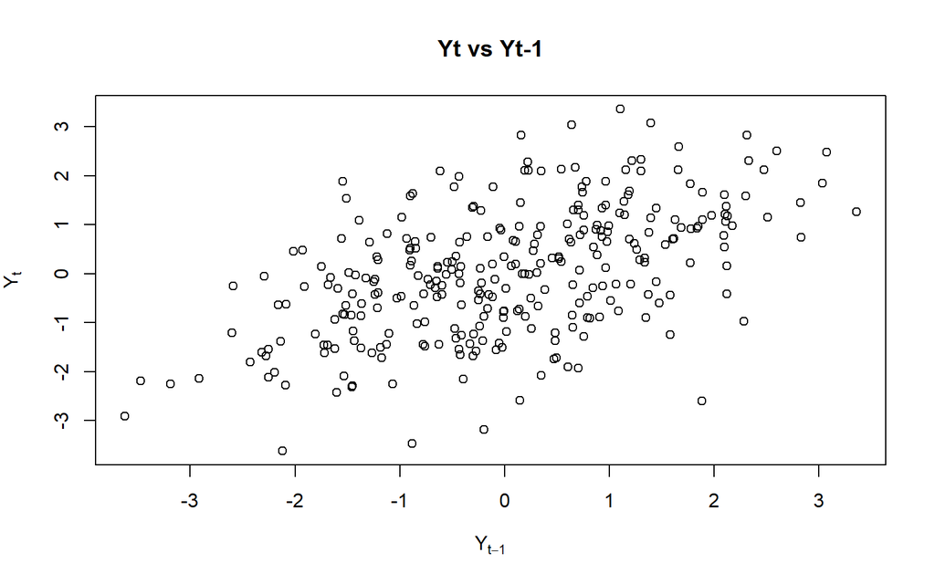

```r
yt_ma1 <- ma2[-1]
yt_1_ma <- ma2[-n]
plot(y=yt_ma1, x=yt_1_ma, xlab=expression(Y[t-1]), ylab=expression(Y[t]), main="Yt vs Yt-1")
```

```r
cor(yt_ma1, yt_1_ma)
```

```
## [1] 0.5274606
```

Terlihat adanya hubungan positif antara $Y_t$ dengan $Y_{t-1}$.

### Korelasi antara $Y_t$ dengan $Y_{t-2}$

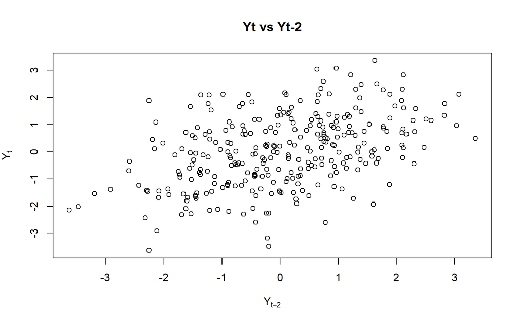

```r
yt_ma2 <- ma2[-c(1,2)]
yt_2_ma <- ma2[-c(n-1,n)]
plot(y=yt_ma2, x=yt_2_ma, xlab=expression(Y[t-2]), ylab=expression(Y[t]), main="Yt vs Yt-2")
```

```r
cor(yt_ma2, yt_2_ma)
```

```
## [1] 0.4339293
```

Masih terlihat hubungan positif (lebih lemah) antara $Y_t$ dengan $Y_{t-2}$ karena keduanya masih berbagi komponen *white noise* $e_{t-2}$.

### Korelasi antara $Y_t$ dengan $Y_{t-3}$

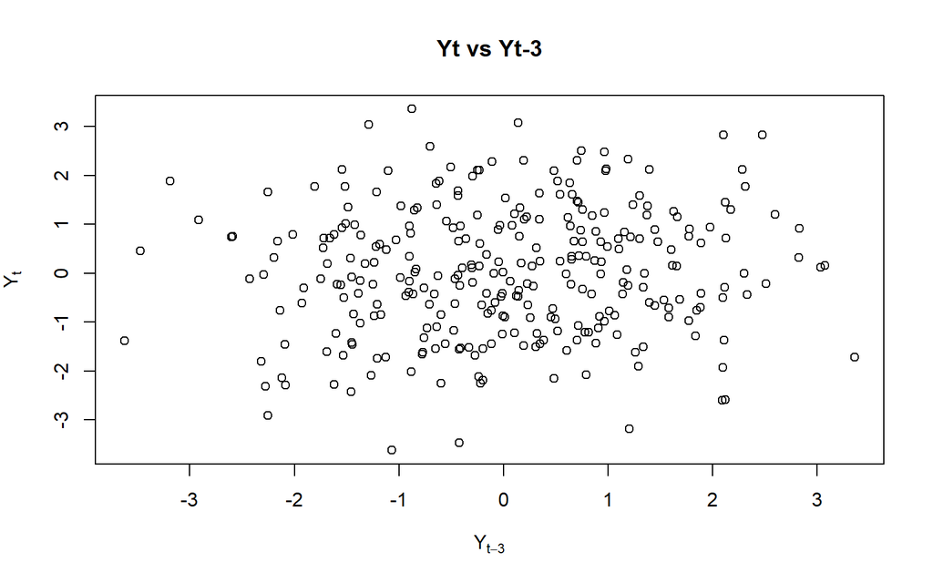

```r
yt_ma3 <- ma2[-c(1,2,3)]
yt_3_ma <- ma2[-c(n-2,n-1,n)]
plot(y=yt_ma3, x=yt_3_ma, xlab=expression(Y[t-3]), ylab=expression(Y[t]), main="Yt vs Yt-3")
```

```r
cor(yt_ma3, yt_3_ma)
```

```
## [1] 0.08555282
```

Terlihat bahwa cenderung tidak terdapat hubungan antara $Y_t$ dengan $Y_{t-3}$ karena keduanya tidak lagi berbagi komponen *white noise* yang sama (sesuai orde MA(2)).

## Autokorelasi: Empiris vs Teoritis

Secara teoritis, untuk proses MA(2):

$$\rho_1=\frac{\theta_1+\theta_1\theta_2}{1+\theta_1^2+\theta_2^2}, \qquad
\rho_2=\frac{\theta_2}{1+\theta_1^2+\theta_2^2}, \qquad
\rho_k=0,\ k\ge3$$

```r
rho1.ma.teori <- (theta1 + theta1*theta2)/(1+theta1^2+theta2^2)
rho2.ma.teori <- theta2/(1+theta1^2+theta2^2)
rho3.ma.teori <- 0

rho.ma.empiris <- c(cor(yt_ma1,yt_1_ma), cor(yt_ma2,yt_2_ma), cor(yt_ma3,yt_3_ma))
rho.ma.teori   <- c(rho1.ma.teori, rho2.ma.teori, rho3.ma.teori)

data.frame(Lag=1:3, Empiris=rho.ma.empiris, Teoritis=rho.ma.teori)
```

```
##   Lag    Empiris  Teoritis
## 1   1 0.52746057 0.4210526
## 2   2 0.43392925 0.3947368
## 3   3 0.08555282 0.0000000
```

Nilai korelasi hasil simulasi pada lag 1 dan lag 2 mendekati nilai teoritisnya, sedangkan pada lag 3 mendekati nol. Hal ini konsisten dengan sifat MA(2) yang ACF-nya terputus (*cuts off*) setelah lag ke-2.

# Bagian 2: Proses AR(2)

## Model AR(2)

Proses AR(2) dapat dituliskan sebagai berikut:

$$Y_t = e_t+\phi_1Y_{t-1}+\phi_2Y_{t-2}$$

dengan $\phi_1=0.5$ dan $\phi_2=0.2$.

## Pembangkitan Data

### Secara Manual

```r
set.seed(1234)
phi1 <- 0.5
phi2 <- 0.2
wn.ar2 <- rnorm(n)

ar2 <- c(1:n)
for(i in 3:n){
  ar2[i] <- phi1*ar2[i-1] + phi2*ar2[i-2] + wn.ar2[i]
}
head(ar2, 10)
```

```
##  [1]  1.0000000  2.0000000  2.2844412 -0.8034771  0.4842744  0.5874977
##  [7] -0.1841363 -0.5212005 -0.8618795 -1.4252177
```

### Menggunakan `arima.sim()`

```r
set.seed(1234)
ar2.sim <- arima.sim(list(order=c(2,0,0), ar=c(phi1,phi2)), n=n)
head(ar2.sim, 10)
```

```
## Time Series:
## Start = 1
## End = 10
## Frequency = 1
##  [1] -1.70663256 -0.40405718 -1.56701082 -0.87945515 -1.68907834  0.08186735
##  [7] -0.77247507 -1.07930411 -1.19540513 -2.44265685
```

## Karakteristik AR(2)

### Plot Time Series

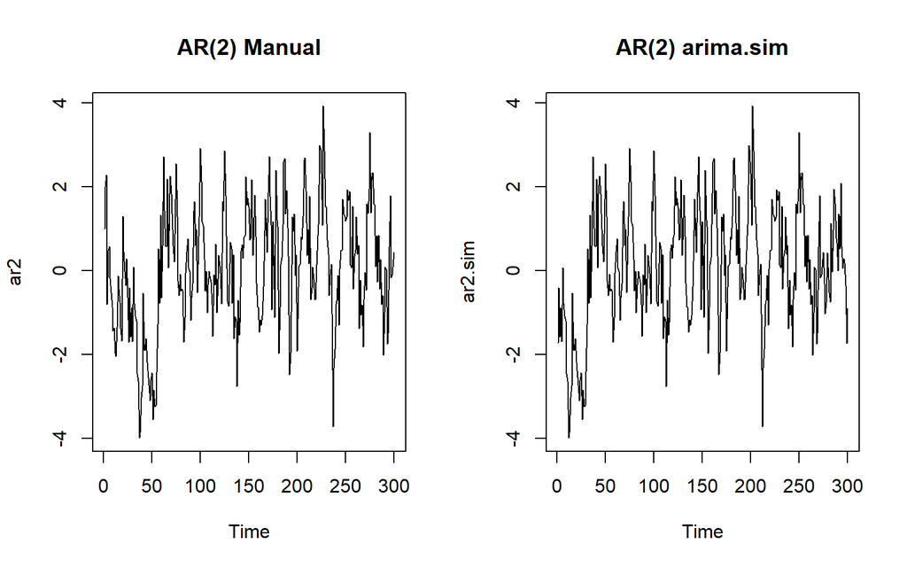

```r
par(mfrow=c(1,2))
ts.plot(ar2, main="AR(2) Manual")
ts.plot(ar2.sim, main="AR(2) arima.sim")
```

```r
par(mfrow=c(1,1))
```

Terlihat bahwa data berfluktuasi di sekitar suatu rataan yang konstan tanpa tren, mengindikasikan data **stasioner dalam rataan**.

### Plot ACF

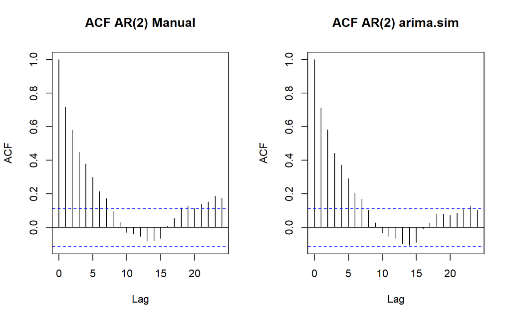

```r
par(mfrow=c(1,2))
acf(ar2, main="ACF AR(2) Manual")
acf(ar2.sim, main="ACF AR(2) arima.sim")
```

```r
par(mfrow=c(1,1))
```

Terlihat bahwa plot ACF cenderung *tails off* (meluruh secara eksponensial), sesuai dengan teori proses AR.

### Plot PACF

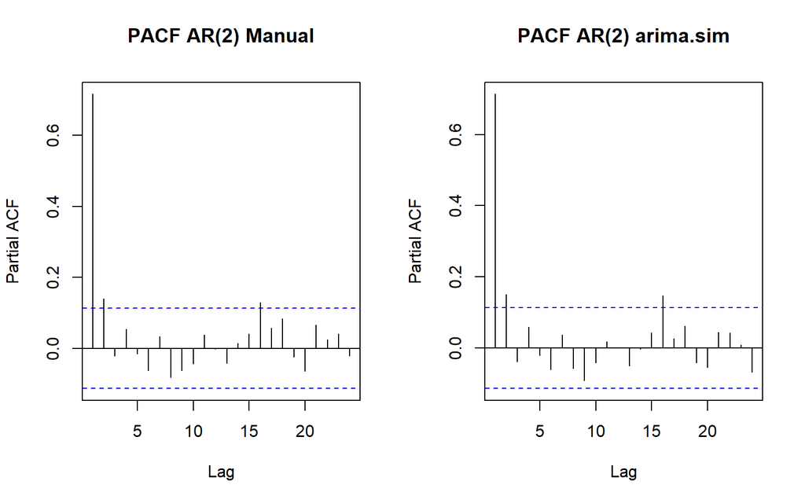

```r
par(mfrow=c(1,2))
pacf(ar2, main="PACF AR(2) Manual")
pacf(ar2.sim, main="PACF AR(2) arima.sim")
```

```r
par(mfrow=c(1,1))
```

Terlihat bahwa plot PACF *cuts off* setelah lag ke-2, sejalan dengan teori bahwa PACF proses AR(p) terputus setelah lag ke-$p$.

### Plot EACF

```r
TSA::eacf(ar2)
```

```
## AR/MA
##   0 1 2 3 4 5 6 7 8 9 10 11 12 13
## 0 x x x x x x x o o o o  o  o  o
## 1 x o o o o o o o o o o  o  o  o
## 2 x o o o o o o o o o o  o  o  o
## 3 x x o o o o o o o o o  o  o  o
## 4 x x o o o o o o o o o  o  o  o
## 5 x x x x o o x o o o o  o  o  o
## 6 x x x x o o o o o o o  o  o  o
## 7 x x x o x x o o o o o  o  o  o
```

```r
TSA::eacf(ar2.sim)
```

```
## AR/MA
##   0 1 2 3 4 5 6 7 8 9 10 11 12 13
## 0 x x x x x x x o o o o  o  o  o
## 1 x o o o o o o o o o o  o  o  o
## 2 x o o o o o o o o o o  o  o  o
## 3 x x o o o o o o o o o  o  o  o
## 4 x x o o o o o o o o o  o  o  o
## 5 x x x o o o o o o o o  o  o  o
## 6 x x x o o o o o o o o  o  o  o
## 7 x x x o x x o o o o o  o  o  o
```

### Identifikasi Kestasioneran

Syarat kestasioneran proses AR(2) adalah:

$$\phi_2<1, \qquad \phi_1+\phi_2<1, \qquad \phi_2-\phi_1<1$$

```r
phi2 < 1
```

```
## [1] TRUE
```

```r
phi1 + phi2 < 1
```

```
## [1] TRUE
```

```r
phi2 - phi1 < 1
```

```
## [1] TRUE
```

Ketiga syarat terpenuhi, sehingga secara teoritis proses AR(2) dengan $\phi_1=0.5$ dan $\phi_2=0.2$ bersifat **stasioner**. Hal ini didukung oleh plot time series yang berfluktuasi konstan di sekitar rataan serta ACF yang *tails off*.

## Scatterplot Antar Lag

### Korelasi antara $Y_t$ dengan $Y_{t-1}$

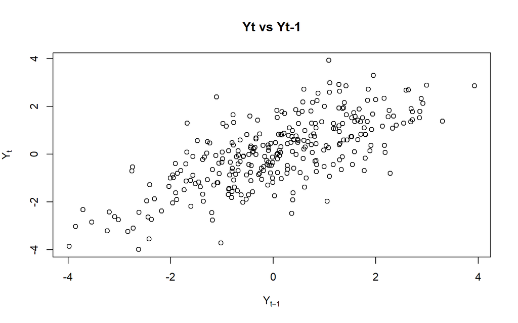

```r
yt_ar1 <- ar2[-1]
yt_1_ar <- ar2[-n]
plot(y=yt_ar1, x=yt_1_ar, xlab=expression(Y[t-1]), ylab=expression(Y[t]), main="Yt vs Yt-1")
```

```r
cor(yt_ar1, yt_1_ar)
```

```
## [1] 0.7173171
```

Terlihat hubungan positif yang cukup kuat antara $Y_t$ dengan $Y_{t-1}$.

### Korelasi antara $Y_t$ dengan $Y_{t-2}$

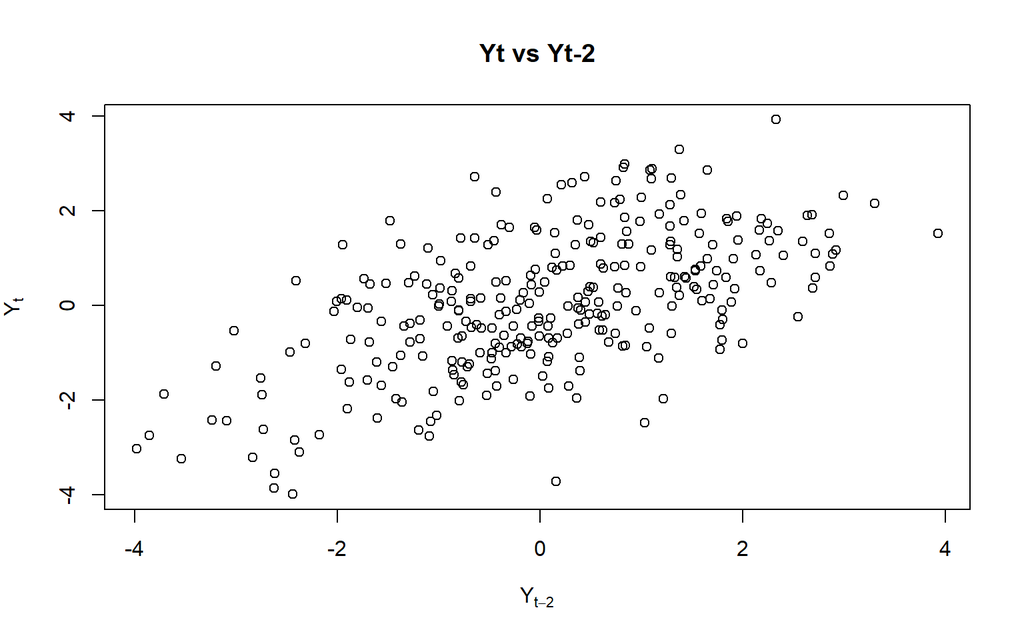

```r
yt_ar2 <- ar2[-c(1,2)]
yt_2_ar <- ar2[-c(n-1,n)]
plot(y=yt_ar2, x=yt_2_ar, xlab=expression(Y[t-2]), ylab=expression(Y[t]), main="Yt vs Yt-2")
```

```r
cor(yt_ar2, yt_2_ar)
```

```
## [1] 0.5836665
```

Masih terlihat hubungan positif antara $Y_t$ dengan $Y_{t-2}$, meskipun sedikit lebih lemah dibandingkan lag pertama.

### Korelasi antara $Y_t$ dengan $Y_{t-3}$

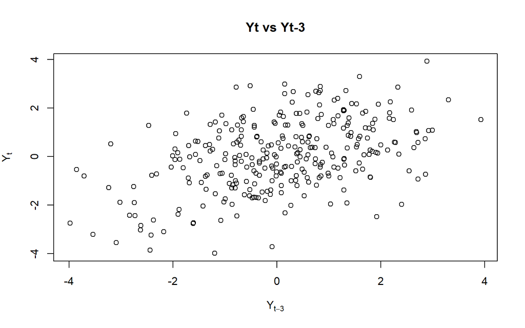

```r
yt_ar3 <- ar2[-c(1,2,3)]
yt_3_ar <- ar2[-c(n-2,n-1,n)]
plot(y=yt_ar3, x=yt_3_ar, xlab=expression(Y[t-3]), ylab=expression(Y[t]), main="Yt vs Yt-3")
```

```r
cor(yt_ar3, yt_3_ar)
```

```
## [1] 0.4522274
```

Hubungan antara $Y_t$ dengan $Y_{t-3}$ masih positif namun semakin melemah, sesuai dengan sifat ACF proses AR yang meluruh secara bertahap (*tails off*), bukan langsung terputus.

## Autokorelasi: Empiris vs Teoritis

Secara teoritis, autokorelasi proses AR(2) mengikuti persamaan Yule-Walker:

$$\rho_1=\frac{\phi_1}{1-\phi_2}, \qquad
\rho_k=\phi_1\rho_{k-1}+\phi_2\rho_{k-2},\ k\ge2,\ \rho_0=1$$

```r
rho1.ar.teori <- phi1/(1-phi2)
rho2.ar.teori <- phi1*rho1.ar.teori + phi2*1
rho3.ar.teori <- phi1*rho2.ar.teori + phi2*rho1.ar.teori

# verifikasi dengan fungsi ARMAacf()
ARMAacf(ar=c(phi1,phi2), lag.max=3)
```

```
##       0       1       2       3
## 1.00000 0.62500 0.51250 0.38125
```

```r
rho.ar.empiris <- c(cor(yt_ar1,yt_1_ar), cor(yt_ar2,yt_2_ar), cor(yt_ar3,yt_3_ar))
rho.ar.teori   <- c(rho1.ar.teori, rho2.ar.teori, rho3.ar.teori)

data.frame(Lag=1:3, Empiris=rho.ar.empiris, Teoritis=rho.ar.teori)
```

```
##   Lag   Empiris Teoritis
## 1   1 0.7173171  0.62500
## 2   2 0.5836665  0.51250
## 3   3 0.4522274  0.38125
```

Nilai korelasi hasil simulasi pada lag 1, 2, dan 3 mendekati nilai teoritisnya dan sama-sama menurun secara bertahap (*tails off*) seiring bertambahnya lag, sesuai dengan karakteristik proses AR(2).

# Bagian 3: Proses ARMA(2,2)

## Model ARMA(2,2)

Proses ARMA(2,2) dapat dituliskan sebagai berikut:

$$Y_t = \phi_1Y_{t-1}+\phi_2Y_{t-2}+e_t+\theta_1e_{t-1}+\theta_2e_{t-2}$$

dengan $\phi_1=0.5$, $\phi_2=0.2$, $\theta_1=0.4$, dan $\theta_2=0.6$.

## Pembangkitan Data

### Secara Manual

```r
set.seed(1234)
wn.arma <- rnorm(n)

arma22 <- c(1:n)
for(i in 3:n){
  arma22[i] <- phi1*arma22[i-1] + phi2*arma22[i-2] + wn.arma[i] + theta1*wn.arma[i-1] + theta2*wn.arma[i-2]
}
head(arma22, 10)
```

```
##  [1]  1.0000000  2.0000000  1.6711734 -0.5098770  0.2208065 -0.7212850
##  [7] -0.4313240 -0.8328133 -1.6306202 -2.4256705
```

### Menggunakan `arima.sim()`

```r
set.seed(1234)
arma22.sim <- arima.sim(list(order=c(2,0,2), ar=c(phi1,phi2), ma=c(theta1,theta2)), n=n)
head(arma22.sim, 10)
```

```
## Time Series:
## Start = 1
## End = 10
## Frequency = 1
##  [1] -2.751891 -1.748143 -2.980647 -1.121117 -1.752931 -1.338988 -2.090470
##  [8] -3.568293 -4.322252 -6.499328
```

## Karakteristik ARMA(2,2)

### Plot Time Series

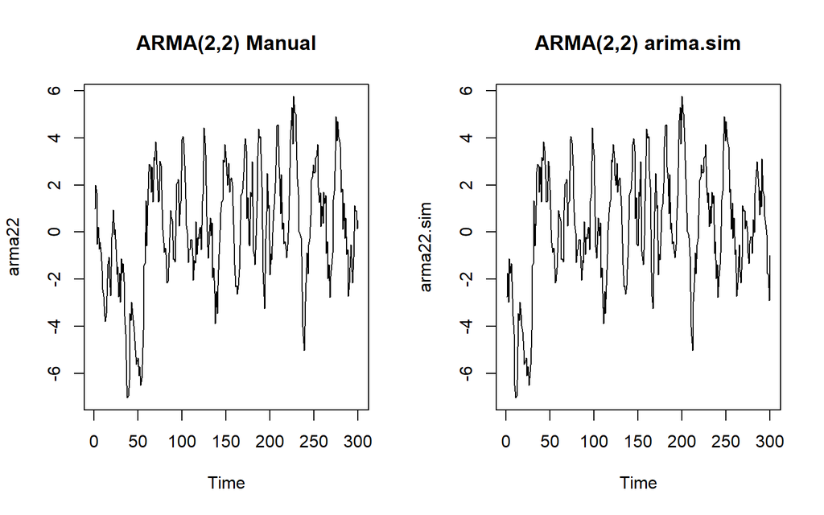

```r
par(mfrow=c(1,2))
ts.plot(arma22, main="ARMA(2,2) Manual")
ts.plot(arma22.sim, main="ARMA(2,2) arima.sim")
```

```r
par(mfrow=c(1,1))
```

Terlihat bahwa data berfluktuasi di sekitar rataan yang konstan tanpa tren, mengindikasikan data **stasioner dalam rataan**.

### Plot ACF

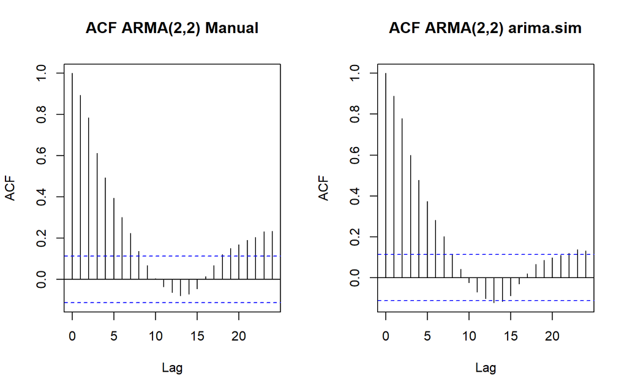

```r
par(mfrow=c(1,2))
acf(arma22, main="ACF ARMA(2,2) Manual")
acf(arma22.sim, main="ACF ARMA(2,2) arima.sim")
```

```r
par(mfrow=c(1,1))
```

Terlihat bahwa plot ACF cenderung *tails off*, sesuai dengan teori bahwa ACF proses ARMA campuran meluruh secara bertahap.

### Plot PACF

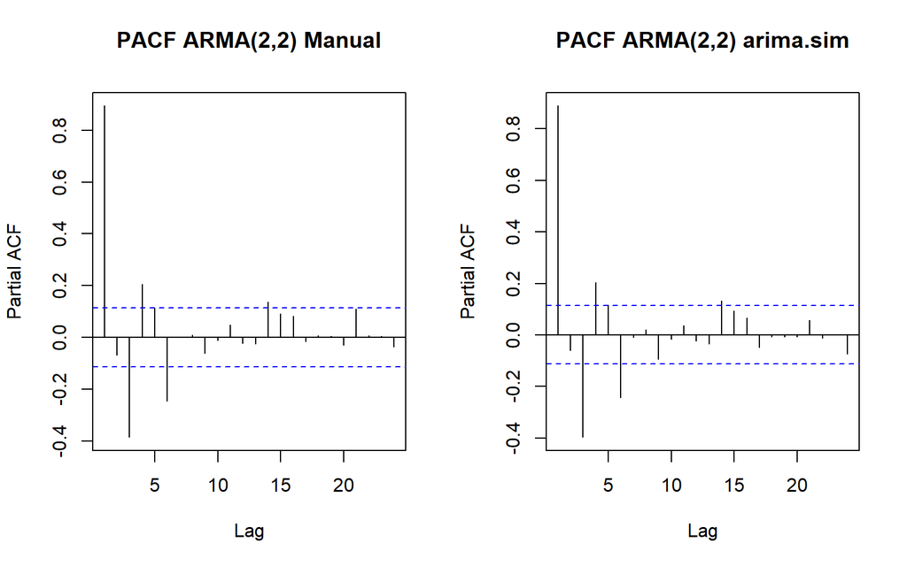

```r
par(mfrow=c(1,2))
pacf(arma22, main="PACF ARMA(2,2) Manual")
pacf(arma22.sim, main="PACF ARMA(2,2) arima.sim")
```

```r
par(mfrow=c(1,1))
```

Terlihat bahwa plot PACF juga cenderung *tails off*, sesuai dengan teori bahwa baik ACF maupun PACF proses ARMA(p,q) dengan $p>0$ dan $q>0$ meluruh secara bertahap dan tidak terputus tegas pada lag tertentu.

### Plot EACF

```r
TSA::eacf(arma22)
```

```
## AR/MA
##   0 1 2 3 4 5 6 7 8 9 10 11 12 13
## 0 x x x x x x x x o o o  o  o  o
## 1 o x o o o o x o o o o  o  o  o
## 2 x x o o o o x o o o o  o  o  o
## 3 x x o x o o x o o o o  o  o  o
## 4 x x x x o o x o o o o  o  o  o
## 5 x x x x x x x o o o o  o  o  o
## 6 o o x o x x o o o o o  o  o  o
## 7 x o x o x x o x o o o  o  o  o
```

```r
TSA::eacf(arma22.sim)
```

```
## AR/MA
##   0 1 2 3 4 5 6 7 8 9 10 11 12 13
## 0 x x x x x x x o o o o  o  x  o
## 1 o x o o o o x o o o o  o  o  o
## 2 x x o o o o o o o o o  o  o  o
## 3 x x x x o o o o o o o  o  o  o
## 4 x x x x o o o o o o o  o  o  o
## 5 x x x x x x x o o o o  o  o  o
## 6 o o x o x x o o o o o  o  o  o
## 7 x o x x x x o x o o o  o  o  o
```

Berdasarkan pola segitiga nol pada plot EACF, terlihat bahwa segitiga nol berada pada sekitar ordo AR(2) dan ordo MA(2), sesuai dengan model yang dibangkitkan.

### Identifikasi Kestasioneran dan Keterbalikan (Invertibility)

Komponen AR dari ARMA(2,2) memiliki koefisien yang sama dengan Bagian AR(2), sehingga syarat kestasioneran berikut tetap harus diperiksa:

```r
phi2 < 1
```

```
## [1] TRUE
```

```r
phi1 + phi2 < 1
```

```
## [1] TRUE
```

```r
phi2 - phi1 < 1
```

```
## [1] TRUE
```

Ketiga syarat terpenuhi sehingga komponen AR **stasioner**. Selanjutnya, keterbalikan (invertibility) komponen MA diperiksa melalui akar-akar polinomial $1+\theta_1B+\theta_2B^2=0$, yang harus berada di luar lingkaran satuan (modulus $>1$):

```r
akar.ma <- polyroot(c(1, theta1, theta2))
akar.ma
```

```
## [1] -0.3333333+1.247219i -0.3333333-1.247219i
```

```r
Mod(akar.ma)
```

```
## [1] 1.290994 1.290994
```

Karena modulus seluruh akar lebih besar dari 1, komponen MA bersifat **invertible**. Dengan demikian, proses ARMA(2,2) yang dibangkitkan bersifat stasioner dan invertible, konsisten dengan plot time series yang stabil di sekitar rataan konstan.

## Scatterplot Antar Lag

### Korelasi antara $Y_t$ dengan $Y_{t-1}$

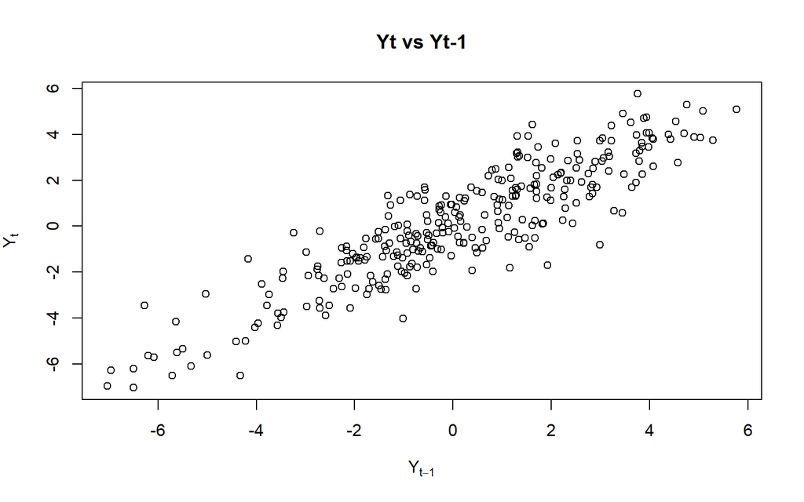

```r
yt_arma1 <- arma22[-1]
yt_1_arma <- arma22[-n]
plot(y=yt_arma1, x=yt_1_arma, xlab=expression(Y[t-1]), ylab=expression(Y[t]), main="Yt vs Yt-1")
```

```r
cor(yt_arma1, yt_1_arma)
```

```
## [1] 0.8943281
```

Terlihat hubungan positif yang cukup kuat antara $Y_t$ dengan $Y_{t-1}$.

### Korelasi antara $Y_t$ dengan $Y_{t-2}$

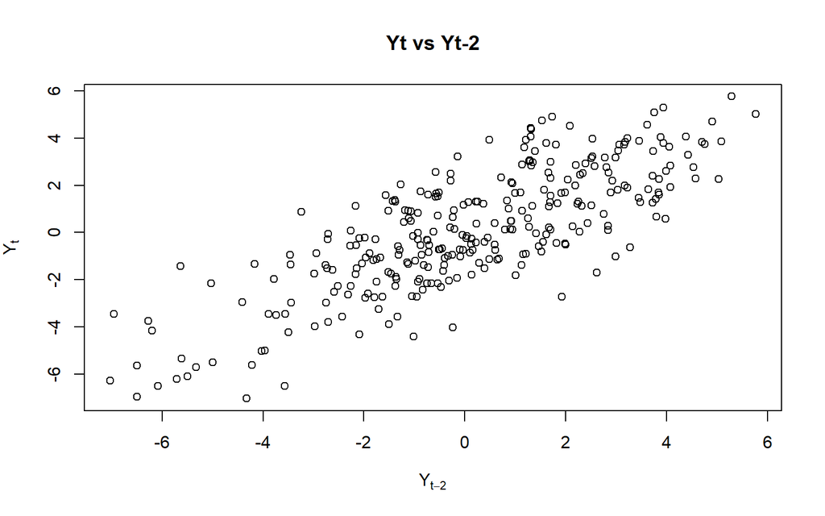

```r
yt_arma2 <- arma22[-c(1,2)]
yt_2_arma <- arma22[-c(n-1,n)]
plot(y=yt_arma2, x=yt_2_arma, xlab=expression(Y[t-2]), ylab=expression(Y[t]), main="Yt vs Yt-2")
```

```r
cor(yt_arma2, yt_2_arma)
```

```
## [1] 0.7865019
```

Masih terlihat hubungan positif antara $Y_t$ dengan $Y_{t-2}$.

### Korelasi antara $Y_t$ dengan $Y_{t-3}$

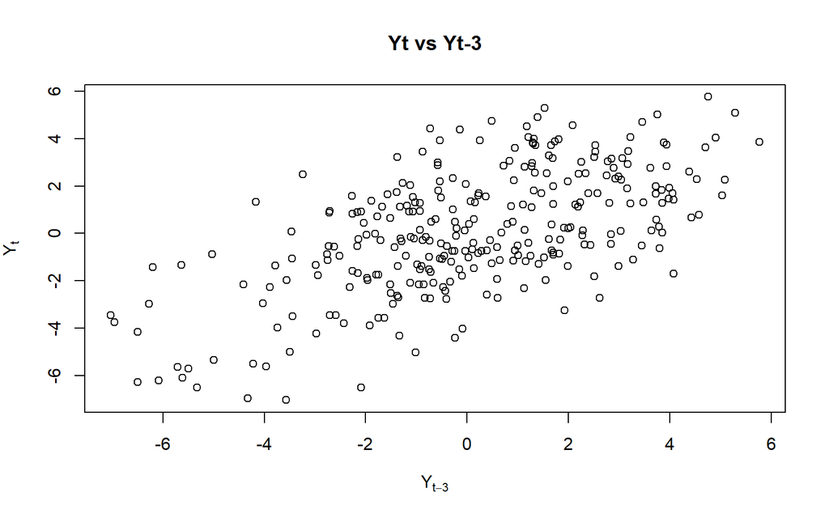

```r
yt_arma3 <- arma22[-c(1,2,3)]
yt_3_arma <- arma22[-c(n-2,n-1,n)]
plot(y=yt_arma3, x=yt_3_arma, xlab=expression(Y[t-3]), ylab=expression(Y[t]), main="Yt vs Yt-3")
```

```r
cor(yt_arma3, yt_3_arma)
```

```
## [1] 0.6135111
```

Hubungan antara $Y_t$ dengan $Y_{t-3}$ masih ada namun semakin melemah seiring bertambahnya lag, sesuai dengan sifat ACF ARMA yang *tails off*.

## Autokorelasi: Empiris vs Teoritis

Untuk proses ARMA campuran, perhitungan autokorelasi teoritis secara aljabar cukup kompleks sehingga dihitung menggunakan fungsi `ARMAacf()`:

```r
rho.arma.teori <- ARMAacf(ar=c(phi1,phi2), ma=c(theta1,theta2), lag.max=3)
rho.arma.teori
```

```
##         0         1         2         3
## 1.0000000 0.8591993 0.7491908 0.5464353
```

```r
rho.arma.empiris <- c(cor(yt_arma1,yt_1_arma), cor(yt_arma2,yt_2_arma), cor(yt_arma3,yt_3_arma))

data.frame(Lag=1:3, Empiris=rho.arma.empiris, Teoritis=as.numeric(rho.arma.teori[1:3]))
```

[output not shown]

Nilai korelasi hasil simulasi mendekati nilai teoritisnya dan menurun secara bertahap (*tails off*) seiring bertambahnya lag, sesuai dengan karakteristik ACF pada proses ARMA(2,2).

# Kesimpulan

| Proses | Plot Time Series | ACF | PACF | Kesimpulan Kestasioneran |
| --- | --- | --- | --- | --- |
| MA(2) | Stabil di sekitar rataan | *cuts off* lag 2 | *tails off* | Stasioner (selalu, tanpa syarat) |
| AR(2) | Stabil di sekitar rataan | *tails off* | *cuts off* lag 2 | Stasioner ($\phi_2<1$, $\phi_1+\phi_2<1$, $\phi_2-\phi_1<1$ terpenuhi) |
| ARMA(2,2) | Stabil di sekitar rataan | *tails off* | *tails off* | Stasioner dan invertible |

Secara umum, nilai autokorelasi empiris hasil pembangkitan data (baik manual maupun `arima.sim()`) untuk ketiga proses mendekati nilai autokorelasi teoritisnya, sehingga pembangkitan data telah sesuai dengan model yang ditentukan.